# Problème du char d’assaut allemand et application concrète sur la vente d’Iphones

### 4. Ces estimations reposent sur l’hypothèse d’uniformité des numéros de série. Que pensez-vous de la validité de cette hypothèse, sur l’ensemble de la période et sur chacune des sous-périodes définies dans la question précédente ?

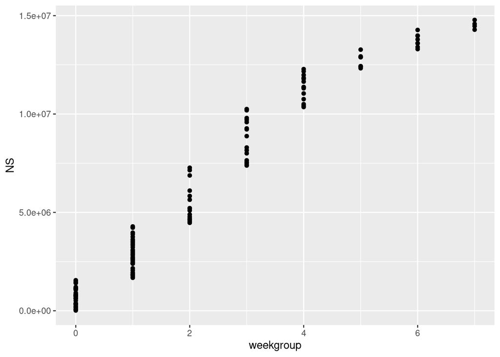

```r
ggplot(iphones.no.X) + geom_point(aes(x = weekgroup, y = NS))
```

Réalisons des tests pour vérifier l’**uniformité** de nos observations.

On choisit $\alpha = 0.01$. On rappelle que p-value < $\alpha$ –> on rejette H0.

H0 est que les observations suivent une distribution uniforme de leur valeur minimale à leur valeur maximale.

```r
# test de Kolmogorov-Smirnov
ks <- function(iphones) {
    return(ks.test(iphones$NS, "punif", min(iphones$NS), max(iphones$NS)))
}

# chi-squared test
chisq <- function(iphones) {
    return(chisq.test(iphones$NS))
}

ks(iphones.no.X)
```

```
##
##  One-sample Kolmogorov-Smirnov test
##
## data:  iphones$NS
## D = 0.23926, p-value = 2.454e-07
## alternative hypothesis: two-sided
```

```r
chisq(iphones.no.X)
```

```
##
##  Chi-squared test for given probabilities
##
## data:  iphones$NS
## X-squared = 529757227, df = 138, p-value < 2.2e-16
```

La loi de nos observations n’est pas uniforme. Vérifions cela graphiquement :

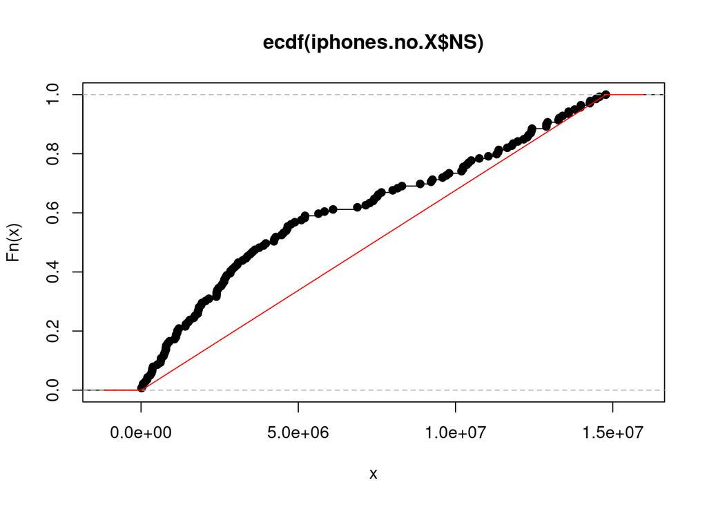

```r
plot(ecdf(iphones.no.X$NS))
curve(punif(x, min(iphones.no.X$NS), max(iphones.no.X$NS)), add = T, col = "red")
```

```r
grouped.summary <- lapply(grouped, iphones.summary)
```

```
##   iphones.mean iphones.median iphones.sd  iphones.var
## 1     722143.6         736180   447916.1 200628825993
##   iphones.mean iphones.median iphones.sd iphones.var
## 1      2804465        2688490   763300.1 5.82627e+11
##   iphones.mean iphones.median iphones.sd iphones.var
## 1      5436946        5151660   952116.1 9.06525e+11
##   iphones.mean iphones.median iphones.sd  iphones.var
## 1      8770412        8876420    1082125 1.170995e+12
##   iphones.mean iphones.median iphones.sd  iphones.var
## 1     11344466       11365535     649001 421202287965
##   iphones.mean iphones.median iphones.sd  iphones.var
## 1     12693872       12660575   345561.7 119412915736
##   iphones.mean iphones.median iphones.sd  iphones.var
## 1     13739324       13694075   326784.8 106788275798
##   iphones.mean iphones.median iphones.sd iphones.var
## 1     14529858       14524960   206269.6 42547148358
```

```r
group.ks.test <- lapply(grouped, ks)
# group.chisq.test <- lapply(grouped, chisq)
```

```r
grouped.mean <- colMeans(Reduce(function(x, y) merge(x, y, all = T), lapply(grouped, estimate)))
print(grouped.mean)
```

```
##      X.1...1.n....m...1 m...min.iphones.NS....1
##                10899075                17722428
```

```r
mean(grouped.mean)
```

```
## [1] 14310752
```

On effectue la moyenne des estimations calculées pour chaque groupement. Pour un échantillon suivant une loi uniforme discrète, je me demande s’il y a équivalence entre appliquer notre estimateur à l’échantillon tout entier ou l’appliquer sur des partitions de l’échantillon puis faire la moyenne des estimations. Je ne pense pas qu’il y ait équivalence. Utiliser la moyenne des estimations obtenues sur les sous-échantillons me semble être une démarche fausse. Je ne saurais pas expliquer pourquoi…

On est plutôt uniforme sur la fin de la distribution

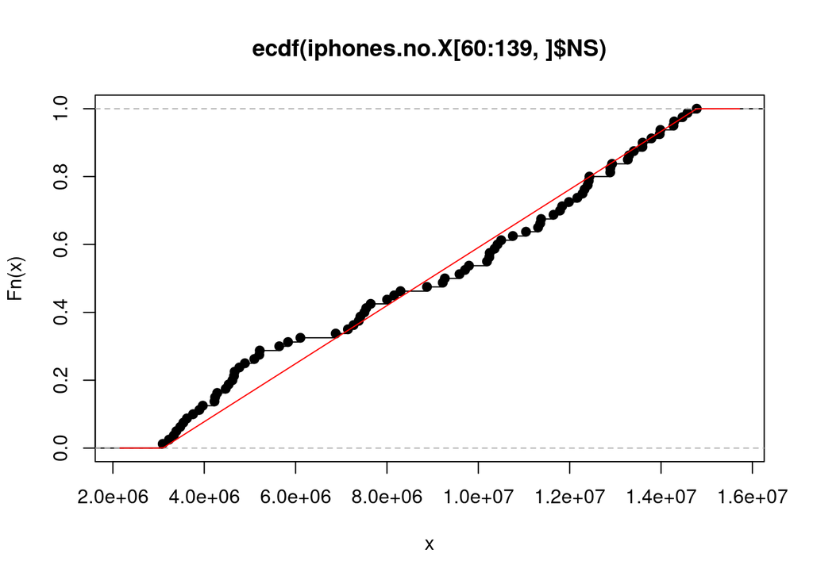

```r
plot(ecdf(iphones.no.X[60:139, ]$NS))
curve(punif(x, min(iphones.no.X[60:139, ]$NS), max(iphones.no.X[60:139, ]$NS)), add = T, col = "red")
```

```r
ks(iphones.no.X[60:139, ])
```

```
##
##  One-sample Kolmogorov-Smirnov test
##
## data:  iphones$NS
## D = 0.10582, p-value = 0.3097
## alternative hypothesis: two-sided
```

```r
estimate(iphones.no.X[60:139, ])
```

| X.1...1.n....m...1 | m...min.iphones.NS....1 |
| --- | --- |
| 14966096 | 17872869 |

On est toujours bon d’après la p-value. La valeur prédite est semblable à celle obtenue sur toute la période. Elle est néanmoins un petit peu plus élevée. C’est celle que je garderais pour estimation.

```r
ks(iphones.no.X[52:139, ])
```

```
##
##  One-sample Kolmogorov-Smirnov test
##
## data:  iphones$NS
## D = 0.14092, p-value = 0.05485
## alternative hypothesis: two-sided
```

Là c’est limite pour la p-value.

### 5. Quelles conclusions tirez-vous de cette étude ?

Production initiale (mise sur le marché) très forte en juin 2008. Cette production a progressivement diminuée (baisse de la demande). Cela explique la non uniformité des numéros de série sur toute la période. On estime que $14966096$ Iphones ont été produits.